# Weather-based logistic regression models for predicting wheat head blast epidemics

Author

Affiliation

Monalisa Cristina de Cól¹, Mauricio A. de Oliveira Coelho², Emerson M. Del Ponte¹

¹Universidade Federal de Vicosa, Vicosa MG, Brazil, ²Campo Experimental de Sertãozinho - Empresa de Pesquisa Agropecuária de Minas Gerais (EPAMIG), Patos de Minas, MG 38700-970, Brazil

Published

Nov 25, 2023

This QMD methodology encompasses data preparation and organization techniques, window creation around the wheat heading date, variable selection employing LASSO and best subset methodologies. It involves applying the logistic model, generating graphs, and conducting model testing using historical data.

# PACKAGES

```r
library(AICcmodavg)
library(bestglm)
library(Boruta)
library(car)
library(caret)
library(cowplot)
library(dplyr)
library(e1071)
library(extrafont)
library(ggplot2)
library(ggthemes)
library(gsheet)
library(gbm)
library(glmnet)
library(gsheet)
library(hrbrthemes)
library(lubridate)
library(magrittr)
library(nasapower)
library(OptimalCutpoints)
library(pROC)
library(PresenceAbsence)
library(patchwork)
library(pROC)
library(reshape2)
library(rpart)
library(rpart.plot)
library(randomForest)
library(tidyverse)
library(tidytext)
library(VGAM)
```

# IMPORTING DATA

## Trial data

```r
trials_data <- gsheet2tbl("https://docs.google.com/spreadsheets/d/1U5_Mz9jvRCbIYZmCJCHXwkbmUVDH6wB717GHiXaptbI/edit#gid=990563228")


summary(trials_data$index_mean)
```

```
   Min. 1st Qu.  Median    Mean 3rd Qu.    Max.
  0.000   0.755  10.230  24.560  40.570 100.000
```

```r
summary(trials_data$inc_mean)
```

```
   Min. 1st Qu.  Median    Mean 3rd Qu.    Max.
   0.00    3.21   25.13   37.31   69.64  100.00
```

```r
trials_data = trials_data |>
  dplyr::select(-yld_mean)
```

###Organizing the trial data

```r
#S1- Adjusting the format of the "heading" variable to a date object S2- Creating two new variables that represent dates 28 days before and 28 days after the original date
trials_setup <- trials_data %>%
  mutate(
    heading = as.Date(heading, format = "%d-%m-%Y") #S1
  ) %>%
  mutate(
    minus28 = heading - 28,
    plus28 = heading + 28
  ) #S2

#S3 - Defining the outbreak and non-outbreak threshold.
trials_setup2 = trials_setup |> filter(!is.na(inc_mean)) %>%
  mutate(epidemic = case_when(
    inc_mean <= 20 ~ 0,
   inc_mean > 20  ~ 1)) |>
  na.omit() #S3


trials_setup2 |> group_by(epidemic) |>
  count()
```

```
# A tibble: 2 × 2
# Groups:   epidemic [2]
  epidemic     n
     <dbl> <int>
1        0    65
2        1    78
```

## Nasa Power

Importing climate data from NASA POWER and saving it

## Weather data

```r
weather_data <- read.csv("G:/.shortcut-targets-by-id/1j8VI38P0Brg7eT5kzCji1n5U9EbAceqw/Monalisa/WB_prediction/mona/WB/weather_data2.csv")
```

## Combining Trials and weather data

```r
data_model2 <- full_join(trials_setup2, weather_data)
```

# WINDOW TIME

Wheat heading date (WHD) was used to create four window time, each comprising two seven-day intervals (before and after WHD)

```r
data_WBTM2 <- data_model2 %>%
  mutate(
    YYYYMMDD = as.Date(YYYYMMDD),
    days = as.numeric(-(heading - YYYYMMDD))
  )

data_WBTM2.1 = data_WBTM2 |>
  mutate(
    single_week = case_when(
      days < -21 ~ "NO",
      days >= -21 & days < -14 ~ "NO",
      days >= -14 & days < -7 ~ "wb2",
      days >= -7 & days <= 0 ~ "wb1",
      days > 0 & days <= 7 ~ "wa1",
      days > 7 & days <= 14 ~ "wa2",
      days > 14 & days <= 21 ~ "NO",
      days > 21 ~ "NO"))
```

# WEATHER VARIABLES

Here, new weather variables were created based on defined conditions. Additionally, some interactions were tested, and those with a correlation greater than 95% were excluded.

```r
data_m2 = data_WBTM2.1 %>%
  # relative humidity
  mutate(
   RH90t = ifelse(RH2M >= 90, 1, 0)
  ) %>%
  # temperature
  mutate(
    ND.TMEAN.22_28 = ifelse(T2M >= 22 & T2M <= 28, 1, 0),
    ND.TMEAN.S22 = ifelse(T2M < 22, 1, 0),
    ND.TMEAN.G28 = ifelse(T2M > 28, 1, 0),

  ) %>%
  # rainfall
  mutate(
    RAIN.ND.G0 = ifelse(PRECTOTCORR > 0, 1, 0),

  ) %>%


  group_by(study, single_week, epidemic) %>%
  summarise(
    # RH
    RH = mean(RH2M),
    RH90 = sum(RH90t),


    # Temperature
    TMEANMAX = mean(T2M_MAX),
    TMEANMIN = mean(T2M_MIN),
    TMEAN = mean(T2M),

    ND.TMEAN.S22 = sum(ND.TMEAN.S22),

    # Rain
    RAINSUM = sum(PRECTOTCORR),
    RAIN.ND.G0 = sum(RAIN.ND.G0),

# Interactions
#TminRH = TMEANMIN * RH ,
#TminRainsum = TMEANMIN * RAINSUM,
#TminRH90 = TMEANMIN * RH90,
TmeanRH= TMEAN * RH)
#TmeanRainsum= TMEAN * RAINSUM,
#TmeanRH90= TMEAN * RH90)
```

## Correlation

```r
data_cor = data_m2 |>
 ungroup() |>
  dplyr::select(-study, -single_week, -epidemic)

correlationMatrix <- cor(data_cor)
# summarize the correlation matrix
box = data.frame(print(correlationMatrix))
```

```
                       RH       RH90    TMEANMAX   TMEANMIN       TMEAN
RH            1.000000000  0.4124928 -0.58097808  0.1625655 -0.19860961
RH90          0.412492793  1.0000000 -0.43799791 -0.1374554 -0.29625175
TMEANMAX     -0.580978080 -0.4379979  1.00000000  0.6435958  0.88468873
TMEANMIN      0.162565545 -0.1374554  0.64359577  1.0000000  0.92061565
TMEAN        -0.198609610 -0.2962517  0.88468873  0.9206157  1.00000000
ND.TMEAN.S22  0.006946402  0.3263569 -0.31974217 -0.3662671 -0.38167336
RAINSUM       0.494907813  0.6719555 -0.28143642  0.1186202 -0.06659834
RAIN.ND.G0    0.385227900  0.4098240 -0.09788878  0.2155990  0.07634705
TmeanRH       0.689701541  0.1024458  0.16111556  0.8107544  0.56671323
             ND.TMEAN.S22     RAINSUM  RAIN.ND.G0    TmeanRH
RH            0.006946402  0.49490781  0.38522790  0.6897015
RH90          0.326356898  0.67195554  0.40982398  0.1024458
TMEANMAX     -0.319742168 -0.28143642 -0.09788878  0.1611156
TMEANMIN     -0.366267097  0.11862023  0.21559896  0.8107544
TMEAN        -0.381673358 -0.06659834  0.07634705  0.5667132
ND.TMEAN.S22  1.000000000  0.35414153  0.50231376 -0.2671259
RAINSUM       0.354141531  1.00000000  0.75350806  0.3553719
RAIN.ND.G0    0.502313756  0.75350806  1.00000000  0.3710892
TmeanRH      -0.267125880  0.35537189  0.37108916  1.0000000
```

```r
# find attributes that are highly corrected (ideally >0.75)
highlyCorrelated <- findCorrelation(correlationMatrix, cutoff=0.5)
```

# COMBINING WEATHER VARIABLES WITH WINDOW TIME

```r
one_week_datam2 =  data_m2 |>
  pivot_wider(
    names_from = single_week,
    values_from = c(
      RH,
      RH90,
      TMEANMAX,
    TMEANMIN,
    TMEAN,
     ND.TMEAN.S22,
    RAINSUM,
    RAIN.ND.G0,TmeanRH
    ))
```

## Organizing the data

```r
one_week_data_m2 <- one_week_datam2 %>%
  dplyr::select(-ends_with("NO"))

data_var2 <-one_week_data_m2
data_var2 <- data_var2 %>%
  ungroup()

data_varm2 = data_var2 |>
  dplyr::select(-study)
```

# LASSO

Selecting predictor variables

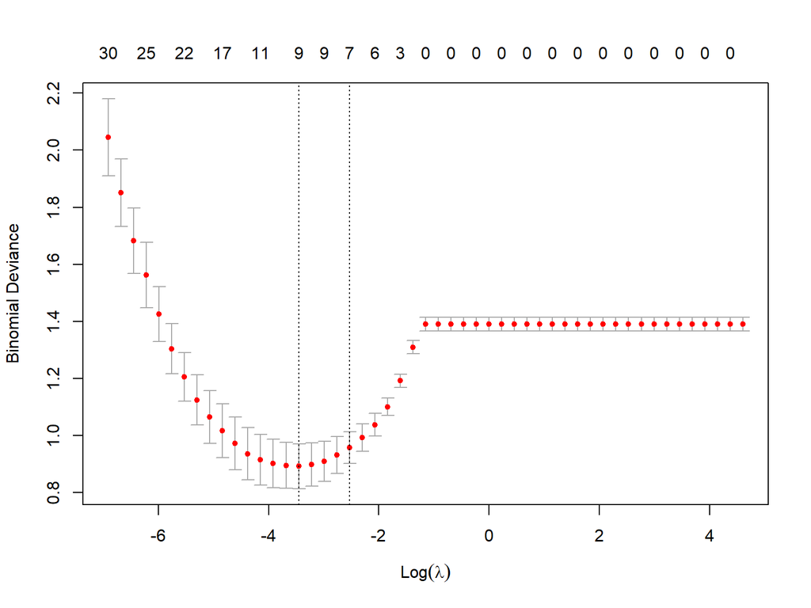

```r
set.seed(123)
lambdas <- 10^seq(2, -3, by = -.1)

y <- data_varm2 %>%
  dplyr::select(epidemic) %>%
  as.matrix()

X <- data_varm2%>%
  dplyr::select(-epidemic) %>%
  as.matrix()


# Setting alpha = 1 implements lasso regression
lasso_reg_1week <- cv.glmnet(X, y,
  alpha = 1,
  family = "binomial",
  lambda = lambdas,
  standardize = TRUE,
  nfolds = 5
)
plot(lasso_reg_1week)
```

```r
# Best lambda
lambda_best_1week <- lasso_reg_1week$lambda.min
lambda_best_1week
```

```
[1] 0.03162278
```

```r
lasso_model_1week <- glmnet(X,
  y,
  alpha = 1,
  family = "binomial",
  lambda = lambda_best_1week,
  standardize = TRUE
)

#Selected variables with non-zero coefficients
coef(lasso_model_1week)
```

```
37 x 1 sparse Matrix of class "dgCMatrix"
                            s0
(Intercept)      -1.095896e+01
RH_wa1            5.810600e-02
RH_wa2            .
RH_wb1            2.471158e-03
RH_wb2            5.290620e-02
RH90_wa1          .
RH90_wa2          .
RH90_wb1          .
RH90_wb2          .
TMEANMAX_wa1      .
TMEANMAX_wa2      .
TMEANMAX_wb1      .
TMEANMAX_wb2      .
TMEANMIN_wa1      .
TMEANMIN_wa2      .
TMEANMIN_wb1      .
TMEANMIN_wb2      .
TMEAN_wa1         .
TMEAN_wa2         .
TMEAN_wb1         .
TMEAN_wb2         .
ND.TMEAN.S22_wa1  .
ND.TMEAN.S22_wa2  .
ND.TMEAN.S22_wb1  .
ND.TMEAN.S22_wb2 -1.124722e-01
RAINSUM_wa1       2.175559e-02
RAINSUM_wa2       .
RAINSUM_wb1       .
RAINSUM_wb2       .
RAIN.ND.G0_wa1    .
RAIN.ND.G0_wa2    .
RAIN.ND.G0_wb1    1.613767e-02
RAIN.ND.G0_wb2    .
TmeanRH_wa1       .
TmeanRH_wa2       2.144902e-04
TmeanRH_wb1       5.814635e-04
TmeanRH_wb2       1.354389e-03
```

```r
assess.glmnet(lasso_model_1week,
  newx = X,
  newy = y
)
```

```
$deviance
       s0
0.8104007
attr(,"measure")
[1] "Binomial Deviance"

$class
       s0
0.1818182
attr(,"measure")
[1] "Misclassification Error"

$auc
[1] 0.9005917
attr(,"measure")
[1] "AUC"

$mse
      s0
0.259448
attr(,"measure")
[1] "Mean-Squared Error"

$mae
       s0
0.5726682
attr(,"measure")
[1] "Mean Absolute Error"
```

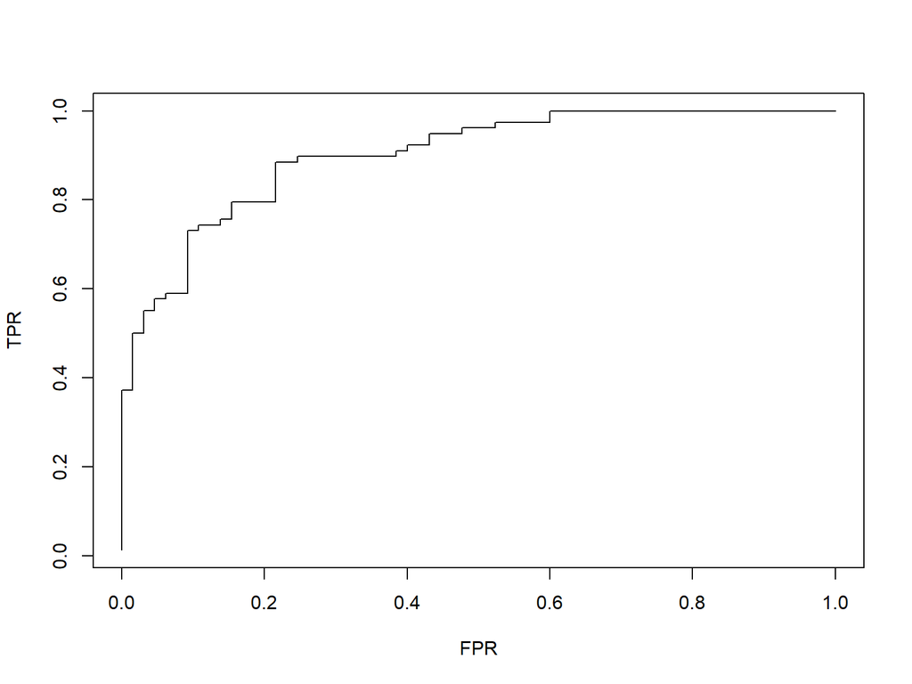

```r
plot(roc.glmnet(lasso_model_1week,
  newx = X,
  newy = factor(y)
),
type = "l"
) # produces
```

# BEST SUBSET

Applying the variables selected by LASSO to obtain the best combinations

```r
#BEST variable
data_v <- data.frame(data_varm2)
dat <- data_v %>%
dplyr::select(epidemic,RH_wa1,
RH_wb1,
RH_wb2 ,
ND.TMEAN.S22_wb2,
RAINSUM_wa1,
RAIN.ND.G0_wb1,
TmeanRH_wa2,
TmeanRH_wb1 ,
TmeanRH_wb2 ) %>%
  mutate(y = epidemic) %>%
  dplyr::select(-1)
dat <- data.frame(dat)

best.logit2 <- bestglm(
  Xy = dat,
  family = binomial,
  IC = "BIC",
  TopModels = 50000,
  method = "exhaustive",
  nvmax = 10
)
summary(best.logit2$BestModel)
```

```
Call:
glm(formula = y ~ ., family = family, data = Xi, weights = weights)

Coefficients:
                  Estimate Std. Error z value Pr(>|z|)
(Intercept)      -10.84637    2.21392  -4.899 9.62e-07 ***
RH_wb2             0.16417    0.03183   5.157 2.51e-07 ***
ND.TMEAN.S22_wb2  -0.32558    0.09317  -3.495 0.000475 ***
RAINSUM_wa1        0.06925    0.02812   2.462 0.013798 *
---
Signif. codes:  0 '***' 0.001 '**' 0.01 '*' 0.05 '.' 0.1 ' ' 1

(Dispersion parameter for binomial family taken to be 1)

    Null deviance: 197.06  on 142  degrees of freedom
Residual deviance: 114.97  on 139  degrees of freedom
AIC: 122.97

Number of Fisher Scoring iterations: 6
```

```r
best.logit2$Subsets
```

```
   Intercept RH_wa1 RH_wb1 RH_wb2 ND.TMEAN.S22_wb2 RAINSUM_wa1 RAIN.ND.G0_wb1
0       TRUE  FALSE  FALSE  FALSE            FALSE       FALSE          FALSE
1       TRUE   TRUE  FALSE  FALSE            FALSE       FALSE          FALSE
2       TRUE   TRUE  FALSE  FALSE            FALSE       FALSE          FALSE
3*      TRUE  FALSE  FALSE   TRUE             TRUE        TRUE          FALSE
4       TRUE  FALSE  FALSE   TRUE             TRUE        TRUE          FALSE
5       TRUE   TRUE  FALSE   TRUE             TRUE        TRUE          FALSE
6       TRUE   TRUE  FALSE   TRUE             TRUE        TRUE          FALSE
7       TRUE   TRUE  FALSE   TRUE             TRUE        TRUE          FALSE
8       TRUE   TRUE   TRUE   TRUE             TRUE        TRUE          FALSE
9       TRUE   TRUE   TRUE   TRUE             TRUE        TRUE           TRUE
   TmeanRH_wa2 TmeanRH_wb1 TmeanRH_wb2 logLikelihood      BIC
0        FALSE       FALSE       FALSE     -98.52832 197.0566
1        FALSE       FALSE       FALSE     -70.31007 145.5830
2        FALSE       FALSE        TRUE     -60.45209 130.8299
3*       FALSE       FALSE       FALSE     -57.48592 129.8604
4        FALSE        TRUE       FALSE     -56.22137 132.2941
5        FALSE        TRUE       FALSE     -55.63621 136.0866
6        FALSE        TRUE        TRUE     -55.49350 140.7641
7         TRUE        TRUE        TRUE     -55.48404 145.7080
8         TRUE        TRUE        TRUE     -55.47857 150.6599
9         TRUE        TRUE        TRUE     -55.47850 155.6226
```

```r
f <- data.frame(best.logit2$Subsets)
```

## Distribution of the top six predictor variables

Fig. 3. Box plots illustrating the distribution of the top six predictor variables of wheat head blast disease in 143 epidemics classified as outbreak (1) and non-outbreak (0).

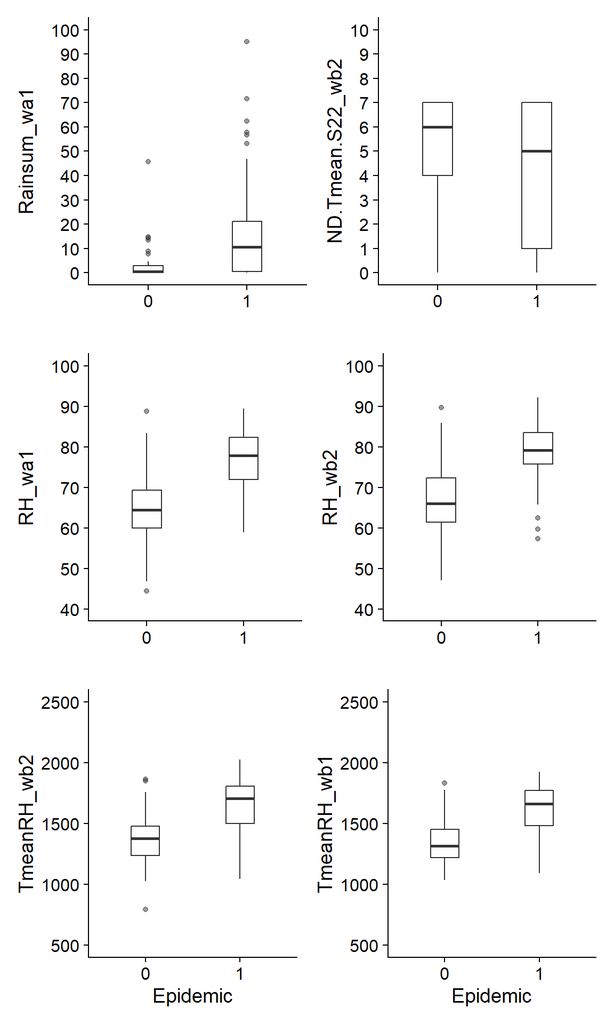

```r
#RAINSUM_wa1
pm1 = data_var2 |>
  ggplot(aes(as.factor(epidemic), RAINSUM_wa1))+
   geom_boxplot( width = 0.3, alpha = 0.5, fill= 'white')+
  theme_half_open()+
  labs(x = "", y = "Rainsum_wa1")+
  scale_y_continuous(breaks = seq(0, 100, 10), limits = c(0, 100))

#ND.TMEAN.S22_wb2
pm2 = data_var2 |>
  ggplot(aes(as.factor(epidemic), ND.TMEAN.S22_wb2))+
  geom_boxplot( width = 0.3, alpha = 0.5, fill= 'white')+
  theme_half_open()+
  labs(x = "", y = "ND.Tmean.S22_wb2")+
  scale_y_continuous(breaks = seq(0, 10, 1), limits = c(0, 10))

#RHM_wa1
pm3 = data_var2 |>
  ggplot(aes(as.factor(epidemic), RH_wa1))+
  geom_boxplot( width = 0.3, alpha = 0.5, fill= 'white')+
  theme_half_open()+
  labs(x = "", y = "RH_wa1")+
  scale_y_continuous(breaks = seq(40, 100, 10), limits = c(40, 100))


#RHM_wb2
pm4 = data_var2 |>
  ggplot(aes(as.factor(epidemic), RH_wb2))+
   geom_boxplot( width = 0.3, alpha = 0.5, fill= 'white')+
  theme_half_open()+
  labs(x = "", y = "RH_wb2")+
  scale_y_continuous(breaks = seq(40, 100, 10), limits = c(40, 100))


#INT4_wb2
pm5 = data_var2 |>
  ggplot(aes(as.factor(epidemic), TmeanRH_wb2))+
  geom_boxplot( width = 0.3, alpha = 0.5, fill= 'white')+
  theme_half_open()+
  labs(x = "Epidemic", y = "TmeanRH_wb2")+
  scale_y_continuous(breaks = seq(500,2500, 500), limits = c(500, 2500))

#INT4_wb1
pm6 = data_var2 |>
  ggplot(aes(as.factor(epidemic), TmeanRH_wb1))+
  geom_boxplot( width = 0.3, alpha = 0.5, fill= 'white')+
  theme_half_open()+
  labs(x = "Epidemic", y = "TmeanRH_wb1")+
  scale_y_continuous(breaks = seq(500, 2500, 500), limits = c(500, 2500))

#joining the plots
(pm1 | pm2)/
( pm3 | pm4)/
  (pm5 | pm6)
```

```r
#Saving
#ggsave("boxplot_m12.png", width = 6 ,  height = 8, bg = "white", dpi = 1000)
```

# LOGISTIC MODEL M2

```r
model_lasso2.2 <- glm(epidemic ~ RH_wa1 + TmeanRH_wb2, family = "binomial",data = data_varm2)
summary(model_lasso2.2)
```

```
Call:
glm(formula = epidemic ~ RH_wa1 + TmeanRH_wb2, family = "binomial",
    data = data_varm2)

Coefficients:
              Estimate Std. Error z value Pr(>|z|)
(Intercept) -15.907922   2.555241  -6.226 4.80e-10 ***
RH_wa1        0.136713   0.029613   4.617 3.90e-06 ***
TmeanRH_wb2   0.004216   0.001026   4.111 3.94e-05 ***
---
Signif. codes:  0 '***' 0.001 '**' 0.01 '*' 0.05 '.' 0.1 ' ' 1

(Dispersion parameter for binomial family taken to be 1)

    Null deviance: 197.06  on 142  degrees of freedom
Residual deviance: 120.90  on 140  degrees of freedom
AIC: 126.9

Number of Fisher Scoring iterations: 5
```

```r
#checking for multicollinearity by using the variance inflation factor
vif(model_lasso2.2)
```

```
     RH_wa1 TmeanRH_wb2
   1.001967    1.001967
```

```r
pred_lasso <- predict(model_lasso2.2, data_varm2, type = "response")

#Better thresholds
dat_lasso <- data.frame(1, data_varm2$epidemic, pred_lasso)
optimal.thresholds(dat_lasso)
```

```
         Method pred_lasso
1       Default  0.5000000
2     Sens=Spec  0.5000000
3  MaxSens+Spec  0.4400000
4      MaxKappa  0.4400000
5        MaxPCC  0.4400000
6  PredPrev=Obs  0.4800000
7       ObsPrev  0.5454545
8      MeanProb  0.5454545
9    MinROCdist  0.4400000
10      ReqSens  0.4400000
11      ReqSpec  0.7200000
12         Cost  0.4400000
```

```r
# Confusion matrix with the MAXsen+spe threshold
confusionMatrix(data = as.factor(as.numeric(pred_lasso > 0.44)),  mode= "everything",  reference = as.factor(data_varm2$epidemic))
```

```
Confusion Matrix and Statistics

          Reference
Prediction  0  1
         0 52 11
         1 13 67

               Accuracy : 0.8322
                 95% CI : (0.7606, 0.8894)
    No Information Rate : 0.5455
    P-Value [Acc > NIR] : 4.172e-13

                  Kappa : 0.6607

 Mcnemar's Test P-Value : 0.8383

            Sensitivity : 0.8000
            Specificity : 0.8590
         Pos Pred Value : 0.8254
         Neg Pred Value : 0.8375
              Precision : 0.8254
                 Recall : 0.8000
                     F1 : 0.8125
             Prevalence : 0.4545
         Detection Rate : 0.3636
   Detection Prevalence : 0.4406
      Balanced Accuracy : 0.8295

       'Positive' Class : 0
```

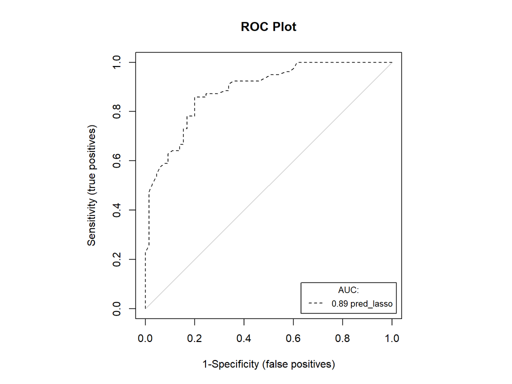

```r
#Plot
auc.roc.plot(dat_lasso)
```

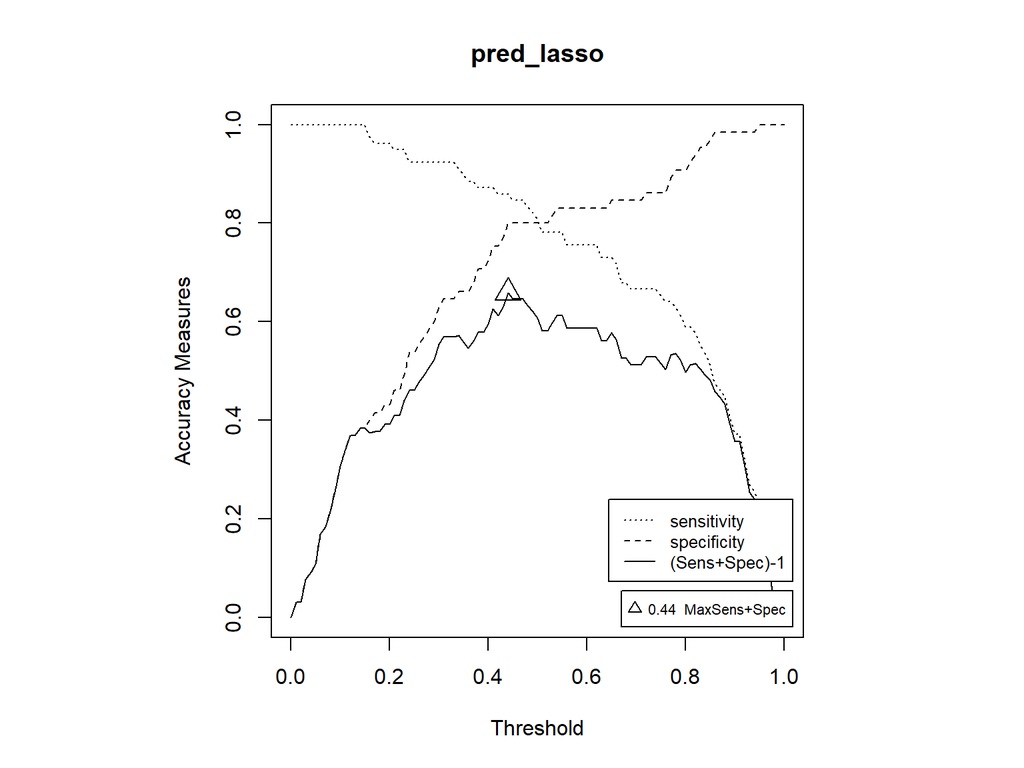

```
   opt.methods threshold       PCC sensitivity specificity     Kappa
1 MaxSens+Spec      0.44 0.8321678   0.8589744         0.8 0.6606684
```

```r
error.threshold.plot(dat_lasso, opt.methods = 3) #takes a single model and plots the sensitivity and specificity as a function of threshold.
```

```r
presence.absence.accuracy(dat_lasso,threshold=.44,st.dev=FALSE) #Calculates five accuracy measures (pcc, sensitivity, specificity, Kappa, and AUC)
```

```
       model threshold       PCC sensitivity specificity     Kappa       AUC
1 pred_lasso      0.44 0.8321678   0.8589744         0.8 0.6606684 0.8865878
```

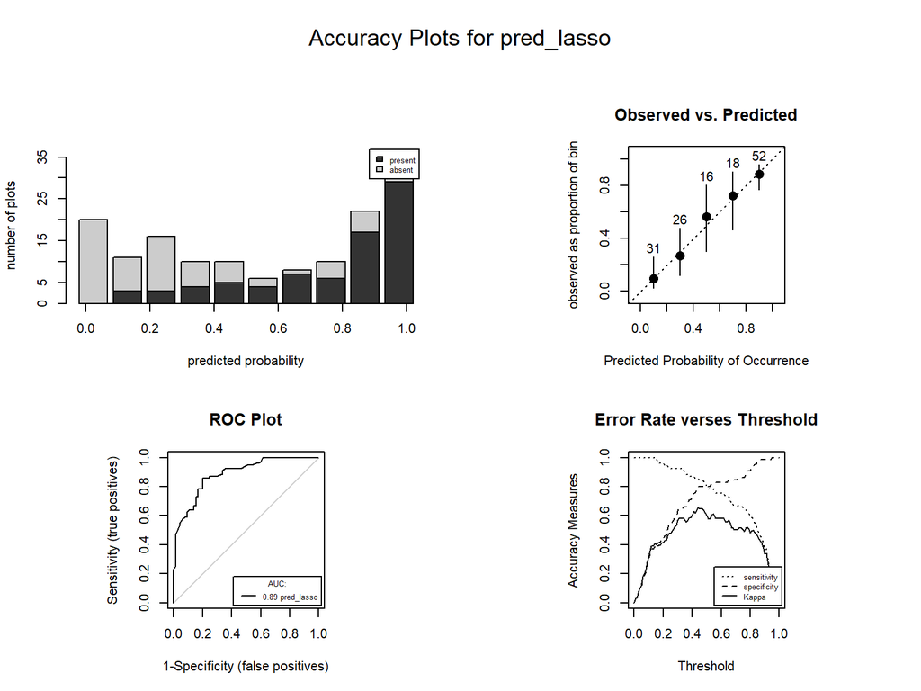

```r
presence.absence.summary(dat_lasso) #Produces four types of Presence/Absence accuracy plots for a single set of model Predictions
```

```r
roc_data2.2 <- roc.plot.calculate(dat_lasso) #data frame
```

## LOOCV

```r
acc <- NULL
for(i in 1:nrow(data_varm2))
{
    # Train-test splitting
    # 499 samples -> fitting
    # 1 sample -> testing
    train <- data_var2[-i,]
    test <- data_var2[i,]

    # Fitting
    model <- glm(epidemic ~ RH_wa1 + TmeanRH_wb2, family=binomial,data=train)

    # Predict results
    results_prob <- predict(model,test,type='response')

    # If prob > 0.5 then 1, else 0
    results <- ifelse(results_prob > 0.44,1,0)

    # Actual answers
    answers <- test$epidemic

    # Calculate accuracy
    misClasificError <- mean(answers != results)

    # Collecting results
    acc[i] <- 1-misClasificError
}

# Average accuracy of the model
mean(acc)
```

```
[1] 0.8111888
```

# LOGISTIC MODEL M3

```r
model_lasso2.3 <- glm(epidemic ~ RH_wb2 + ND.TMEAN.S22_wb2 + RAINSUM_wa1, family = "binomial",data = data_varm2)

summary(model_lasso2.3)
```

```
Call:
glm(formula = epidemic ~ RH_wb2 + ND.TMEAN.S22_wb2 + RAINSUM_wa1,
    family = "binomial", data = data_varm2)

Coefficients:
                  Estimate Std. Error z value Pr(>|z|)
(Intercept)      -10.84637    2.21392  -4.899 9.62e-07 ***
RH_wb2             0.16417    0.03183   5.157 2.51e-07 ***
ND.TMEAN.S22_wb2  -0.32558    0.09317  -3.495 0.000475 ***
RAINSUM_wa1        0.06925    0.02812   2.462 0.013798 *
---
Signif. codes:  0 '***' 0.001 '**' 0.01 '*' 0.05 '.' 0.1 ' ' 1

(Dispersion parameter for binomial family taken to be 1)

    Null deviance: 197.06  on 142  degrees of freedom
Residual deviance: 114.97  on 139  degrees of freedom
AIC: 122.97

Number of Fisher Scoring iterations: 6
```

```r
pred_lasso <- predict(model_lasso2.3, data_varm2, type = "response")

vif(model_lasso2.3)
```

```
          RH_wb2 ND.TMEAN.S22_wb2      RAINSUM_wa1
        1.179073         1.173946         1.009647
```

```r
#Better thresholds
dat_lasso <- data.frame(1, data_varm2$epidemic, pred_lasso)

optimal.thresholds(dat_lasso)
```

```
         Method pred_lasso
1       Default  0.5000000
2     Sens=Spec  0.5700000
3  MaxSens+Spec  0.6800000
4      MaxKappa  0.3450000
5        MaxPCC  0.3450000
6  PredPrev=Obs  0.5200000
7       ObsPrev  0.5454545
8      MeanProb  0.5454545
9    MinROCdist  0.6800000
10      ReqSens  0.4300000
11      ReqSpec  0.6700000
12         Cost  0.3450000
```

```r
# Confusion matrix with the MAXsen+spe threshold
confusionMatrix(data = as.factor(as.numeric(pred_lasso > 0.68)),  mode= "everything",  reference = as.factor(data_varm2$epidemic))
```

```
Confusion Matrix and Statistics

          Reference
Prediction  0  1
         0 59 22
         1  6 56

               Accuracy : 0.8042
                 95% CI : (0.7296, 0.8658)
    No Information Rate : 0.5455
    P-Value [Acc > NIR] : 8.329e-11

                  Kappa : 0.6131

 Mcnemar's Test P-Value : 0.004586

            Sensitivity : 0.9077
            Specificity : 0.7179
         Pos Pred Value : 0.7284
         Neg Pred Value : 0.9032
              Precision : 0.7284
                 Recall : 0.9077
                     F1 : 0.8082
             Prevalence : 0.4545
         Detection Rate : 0.4126
   Detection Prevalence : 0.5664
      Balanced Accuracy : 0.8128

       'Positive' Class : 0
```

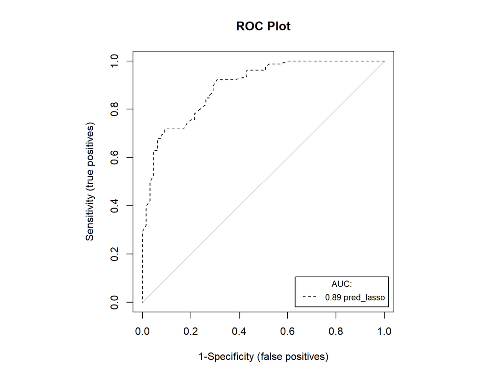

```r
#Plot
 auc.roc.plot(dat_lasso)
```

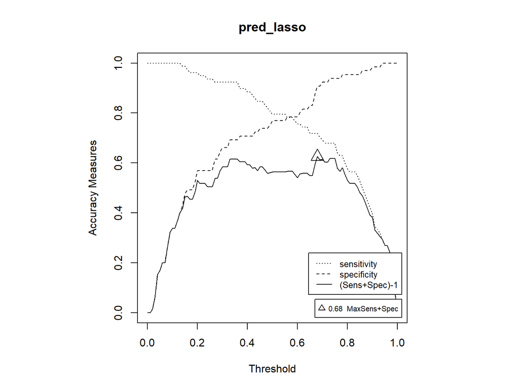

```
   opt.methods threshold       PCC sensitivity specificity     Kappa
1 MaxSens+Spec      0.68 0.8041958   0.7179487   0.9076923 0.6130653
```

```r
#takes a single model and plots the sensitivity and specificity as a function of threshold.
error.threshold.plot(dat_lasso, opt.methods = 3)
```

```r
#Calculates five accuracy measures (pcc, sensitivity, specificity, Kappa, and AUC)
presence.absence.accuracy(dat_lasso,threshold=.68,st.dev=FALSE)
```

```
       model threshold       PCC sensitivity specificity     Kappa       AUC
1 pred_lasso      0.68 0.8041958   0.7179487   0.9076923 0.6130653 0.8948718
```

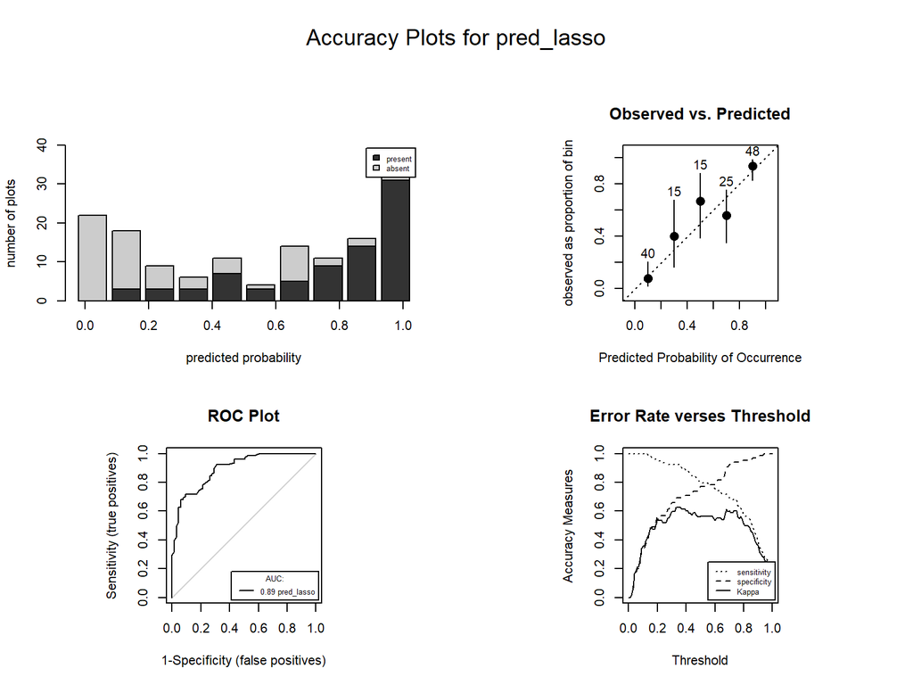

```r
#Produces four types of Presence/Absence accuracy plots for a single set of model Predictions
presence.absence.summary(dat_lasso)
```

```r
roc_data2.3 <- roc.plot.calculate(dat_lasso) #data frame
```

## LOOCV

```r
acc <- NULL
for(i in 1:nrow(data_varm2))
{
    # Train-test splitting
    # 499 samples -> fitting
    # 1 sample -> testing
    train <- data_var2[-i,]
    test <- data_var2[i,]

    # Fitting
    model <- glm(epidemic ~  RH_wb2 + ND.TMEAN.S22_wb2 + RAINSUM_wa1, family=binomial,data=train)

    # Predict results
    results_prob <- predict(model,test,type='response')

    # If prob > 0.5 then 1, else 0
    results <- ifelse(results_prob > 0.68,1,0)

    # Actual answers
    answers <- test$epidemic

    # Calculate accuracy
    misClasificError <- mean(answers != results)

    # Collecting results
    acc[i] <- 1-misClasificError
}

# Average accuracy of the model
mean(acc)
```

```
[1] 0.7552448
```

# LOGISTIC MODEL M4

```r
model_lasso2.4 <- glm(epidemic ~ RH_wb2 +ND.TMEAN.S22_wb2 + RAINSUM_wa1 +  TmeanRH_wb1, family = "binomial",data = data_varm2)

summary(model_lasso2.4)
```

```
Call:
glm(formula = epidemic ~ RH_wb2 + ND.TMEAN.S22_wb2 + RAINSUM_wa1 +
    TmeanRH_wb1, family = "binomial", data = data_varm2)

Coefficients:
                   Estimate Std. Error z value Pr(>|z|)
(Intercept)      -12.984671   2.702899  -4.804 1.56e-06 ***
RH_wb2             0.141427   0.034253   4.129 3.64e-05 ***
ND.TMEAN.S22_wb2  -0.226089   0.111851  -2.021   0.0432 *
RAINSUM_wa1        0.068616   0.027096   2.532   0.0113 *
TmeanRH_wb1        0.002281   0.001443   1.581   0.1140
---
Signif. codes:  0 '***' 0.001 '**' 0.01 '*' 0.05 '.' 0.1 ' ' 1

(Dispersion parameter for binomial family taken to be 1)

    Null deviance: 197.06  on 142  degrees of freedom
Residual deviance: 112.44  on 138  degrees of freedom
AIC: 122.44

Number of Fisher Scoring iterations: 6
```

```r
pred_lasso4 <- predict(model_lasso2.4, data_varm2, type = "response")

vif(model_lasso2.4)
```

```
          RH_wb2 ND.TMEAN.S22_wb2      RAINSUM_wa1      TmeanRH_wb1
        1.350630         1.665290         1.006830         1.429236
```

```r
#Better thresholds
dat_lasso4 <- data.frame(1, data_varm2$epidemic, pred_lasso4)

optimal.thresholds(dat_lasso4)
```

```
         Method pred_lasso4
1       Default   0.5000000
2     Sens=Spec   0.6000000
3  MaxSens+Spec   0.6200000
4      MaxKappa   0.6200000
5        MaxPCC   0.5728571
6  PredPrev=Obs   0.5300000
7       ObsPrev   0.5454545
8      MeanProb   0.5454545
9    MinROCdist   0.6200000
10      ReqSens   0.4900000
11      ReqSpec   0.6200000
12         Cost   0.5728571
```

```r
 # Confusion matrix with the MAXsen+spe threshold
confusionMatrix(data = as.factor(as.numeric(pred_lasso4 > 0.62)),  mode= "everything",  reference = as.factor(data_varm2$epidemic))
```

```
Confusion Matrix and Statistics

          Reference
Prediction  0  1
         0 56 16
         1  9 62

               Accuracy : 0.8252
                 95% CI : (0.7528, 0.8836)
    No Information Rate : 0.5455
    P-Value [Acc > NIR] : 1.681e-12

                  Kappa : 0.6506

 Mcnemar's Test P-Value : 0.2301

            Sensitivity : 0.8615
            Specificity : 0.7949
         Pos Pred Value : 0.7778
         Neg Pred Value : 0.8732
              Precision : 0.7778
                 Recall : 0.8615
                     F1 : 0.8175
             Prevalence : 0.4545
         Detection Rate : 0.3916
   Detection Prevalence : 0.5035
      Balanced Accuracy : 0.8282

       'Positive' Class : 0
```

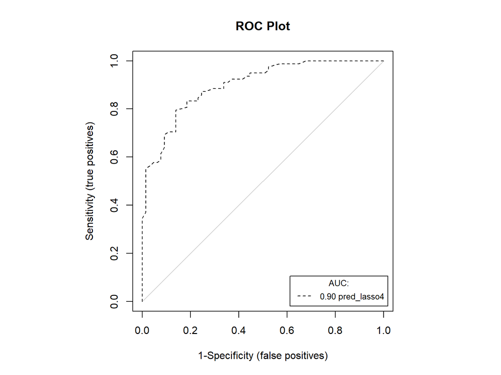

```r
#Plot
auc.roc.plot(dat_lasso4)
```

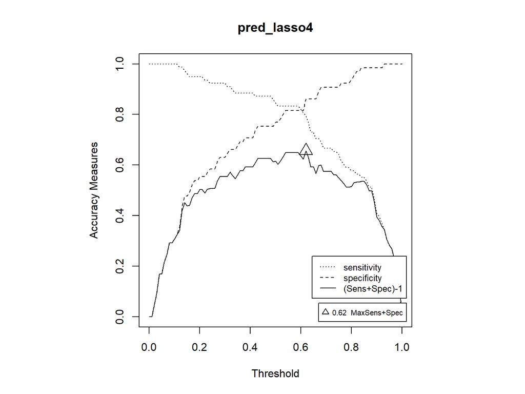

```
   opt.methods threshold       PCC sensitivity specificity     Kappa
1 MaxSens+Spec      0.62 0.8251748   0.7948718   0.8615385 0.6505718
```

```r
#takes a single model and plots the sensitivity and specificity as a function of threshold.
error.threshold.plot(dat_lasso4, opt.methods = 3)
```

```r
#Calculates five accuracy measures (pcc, sensitivity, specificity, Kappa, and AUC)
presence.absence.accuracy(dat_lasso4,threshold=.62,st.dev=FALSE)
```

```
        model threshold       PCC sensitivity specificity     Kappa       AUC
1 pred_lasso4      0.62 0.8251748   0.7948718   0.8615385 0.6505718 0.9003945
```

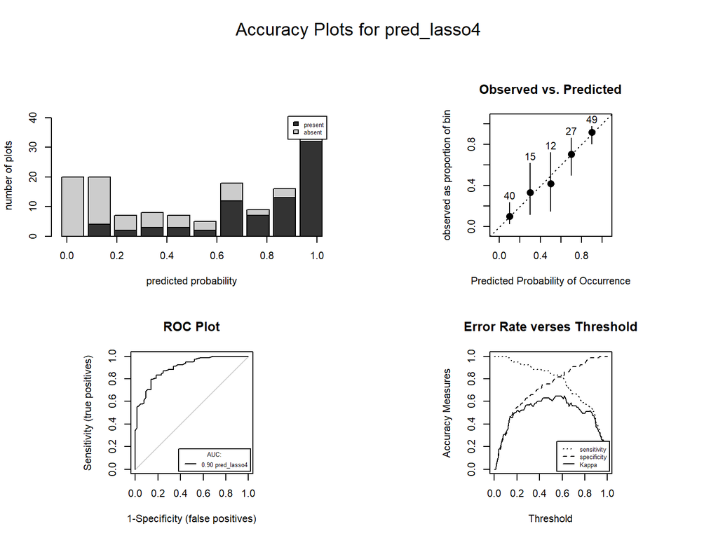

```r
#Produces four types of Presence/Absence accuracy plots for a single set of model Predictions
presence.absence.summary(dat_lasso4)
```

```r
roc_data2.4 <- roc.plot.calculate(dat_lasso4) #data frame
```

##LOOCV

```r
acc <- NULL
for(i in 1:nrow(data_varm2))
{
    # Train-test splitting
    # 499 samples -> fitting
    # 1 sample -> testing
    train <- data_var2[-i,]
    test <- data_var2[i,]

    # Fitting
    model <- glm(epidemic ~ RH_wb2 +ND.TMEAN.S22_wb2 + RAINSUM_wa1 +  TmeanRH_wb1, family=binomial,data=train)

    # Predict results
    results_prob <- predict(model,test,type='response')

    # If prob > 0.5 then 1, else 0
    results <- ifelse(results_prob > 0.62,1,0)

    # Actual answers
    answers <- test$epidemic

    # Calculate accuracy
    misClasificError <- mean(answers != results)

    # Collecting results
    acc[i] <- 1-misClasificError
}

# Average accuracy of the model
mean(acc)
```

```
[1] 0.7692308
```

# LOGISTIC MODEL M5

```r
model_lasso2.5 <- glm(epidemic ~ RH_wa1 + RH_wb2 + ND.TMEAN.S22_wb2+ RAINSUM_wa1 + TmeanRH_wb1, family = binomial(link = 'logit'),data = data_varm2)

summary(model_lasso2.5)
```

```
Call:
glm(formula = epidemic ~ RH_wa1 + RH_wb2 + ND.TMEAN.S22_wb2 +
    RAINSUM_wa1 + TmeanRH_wb1, family = binomial(link = "logit"),
    data = data_varm2)

Coefficients:
                   Estimate Std. Error z value Pr(>|z|)
(Intercept)      -13.633025   2.812068  -4.848 1.25e-06 ***
RH_wa1             0.052137   0.048500   1.075  0.28238
RH_wb2             0.113687   0.042132   2.698  0.00697 **
ND.TMEAN.S22_wb2  -0.264446   0.118634  -2.229  0.02581 *
RAINSUM_wa1        0.052856   0.029852   1.771  0.07663 .
TmeanRH_wb1        0.001763   0.001536   1.148  0.25102
---
Signif. codes:  0 '***' 0.001 '**' 0.01 '*' 0.05 '.' 0.1 ' ' 1

(Dispersion parameter for binomial family taken to be 1)

    Null deviance: 197.06  on 142  degrees of freedom
Residual deviance: 111.27  on 137  degrees of freedom
AIC: 123.27

Number of Fisher Scoring iterations: 6
```

```r
vif(model_lasso2.5)
```

```
          RH_wa1           RH_wb2 ND.TMEAN.S22_wb2      RAINSUM_wa1
        2.580840         2.026634         1.868570         1.301958
     TmeanRH_wb1
        1.582558
```

```r
pred_lasso5 <- predict(model_lasso2.5, data_varm2, type = "response")


#Better thresholds
dat_lasso5 <- data.frame(1, data_varm2$epidemic, pred_lasso5)

optimal.thresholds(dat_lasso5)
```

```
         Method pred_lasso5
1       Default   0.5000000
2     Sens=Spec   0.5700000
3  MaxSens+Spec   0.6400000
4      MaxKappa   0.6400000
5        MaxPCC   0.6400000
6  PredPrev=Obs   0.5500000
7       ObsPrev   0.5454545
8      MeanProb   0.5454545
9    MinROCdist   0.6400000
10      ReqSens   0.4500000
11      ReqSpec   0.6200000
12         Cost   0.6400000
```

```r
# Confusion matrix with the MAXsen+spe threshold
confusionMatrix(data = as.factor(as.numeric(pred_lasso5 > 0.64)),  mode= "everything",  reference = as.factor(data_varm2$epidemic))
```

```
Confusion Matrix and Statistics

          Reference
Prediction  0  1
         0 59 16
         1  6 62

               Accuracy : 0.8462
                 95% CI : (0.7764, 0.901)
    No Information Rate : 0.5455
    P-Value [Acc > NIR] : 2.217e-14

                  Kappa : 0.6937

 Mcnemar's Test P-Value : 0.05501

            Sensitivity : 0.9077
            Specificity : 0.7949
         Pos Pred Value : 0.7867
         Neg Pred Value : 0.9118
              Precision : 0.7867
                 Recall : 0.9077
                     F1 : 0.8429
             Prevalence : 0.4545
         Detection Rate : 0.4126
   Detection Prevalence : 0.5245
      Balanced Accuracy : 0.8513

       'Positive' Class : 0
```

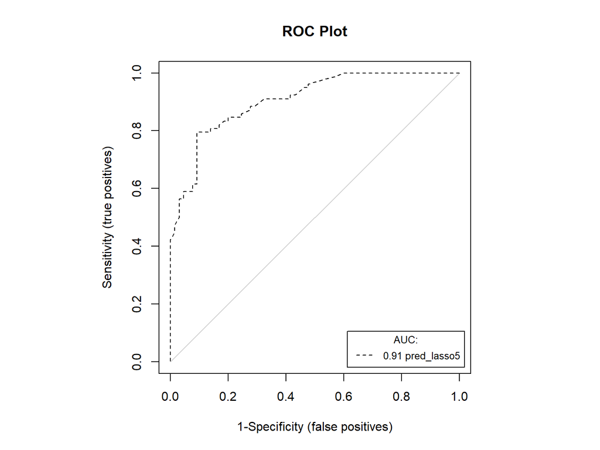

```r
#Plot
auc.roc.plot(dat_lasso5)
```

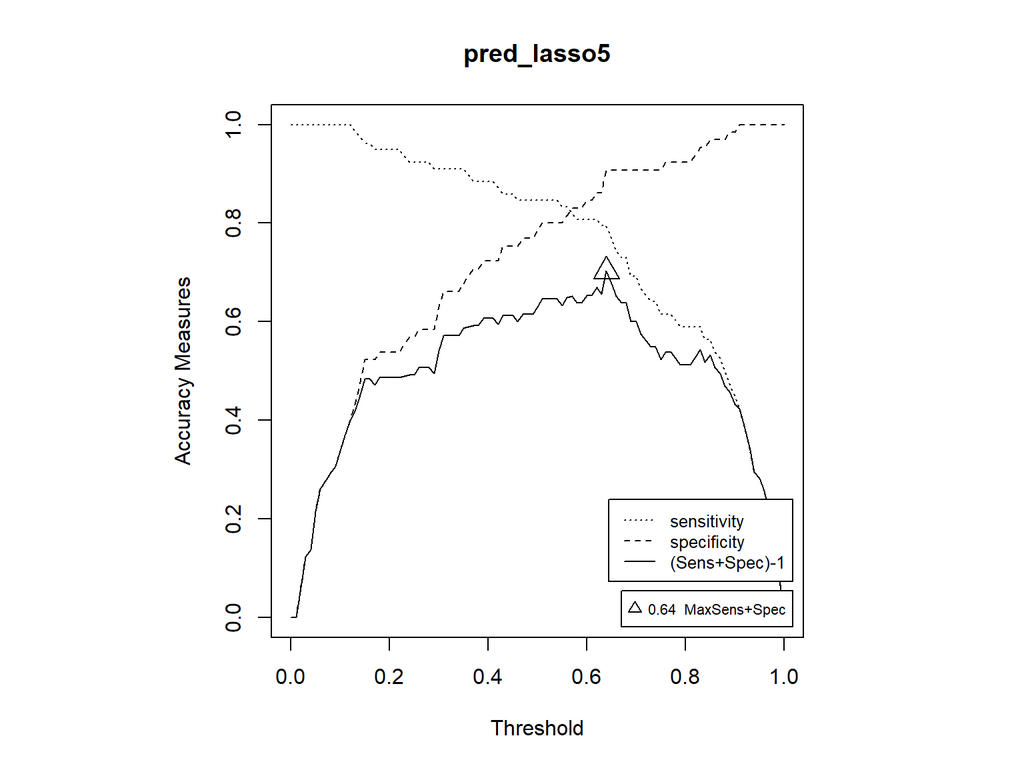

```
   opt.methods threshold       PCC sensitivity specificity     Kappa
1 MaxSens+Spec      0.64 0.8461538   0.7948718   0.9076923 0.6936709
```

```r
#takes a single model and plots the sensitivity and specificity as a function of threshold.
error.threshold.plot(dat_lasso5, opt.methods = 3)
```

```r
 #Calculates five accuracy measures (pcc, sensitivity, specificity, Kappa, and AUC)
presence.absence.accuracy(dat_lasso,threshold=.64,st.dev=FALSE)
```

```
       model threshold       PCC sensitivity specificity     Kappa       AUC
1 pred_lasso      0.64 0.7762238   0.7435897   0.8153846 0.5532995 0.8948718
```

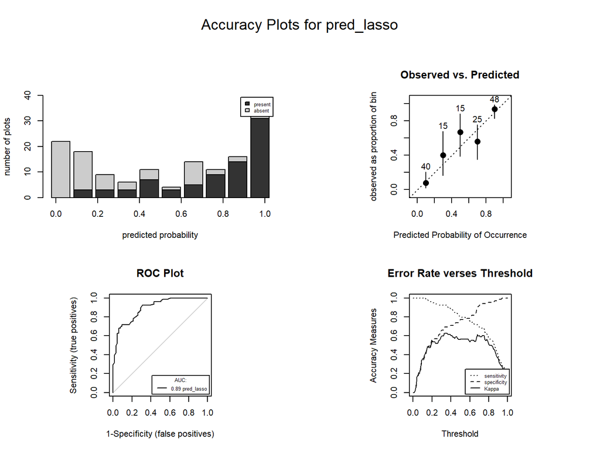

```r
#Produces four types of Presence/Absence accuracy plots for a single set of model Predictions
presence.absence.summary(dat_lasso)
```

```r
roc_data2.4 <- roc.plot.calculate(dat_lasso) #data frame
```

##LOOCV

```r
acc <- NULL
for(i in 1:nrow(data_varm2))
{
    # Train-test splitting
    # 499 samples -> fitting
    # 1 sample -> testing
    train <- data_var2[-i,]
    test <- data_var2[i,]

    # Fitting
    model <- glm(epidemic ~  RH_wa1 + RH_wb2 + ND.TMEAN.S22_wb2+ RAINSUM_wa1 + TmeanRH_wb1, family=binomial,data=train)

    # Predict results
    results_prob <- predict(model,test,type='response')

    # If prob > 0.5 then 1, else 0
    results <- ifelse(results_prob > 0.64,1,0)

    # Actual answers
    answers <- test$epidemic

    # Calculate accuracy
    misClasificError <- mean(answers != results)

    # Collecting results
    acc[i] <- 1-misClasificError
}

# Average accuracy of the model
mean(acc)
```

```
[1] 0.7972028
```

# FIGURE LASSO

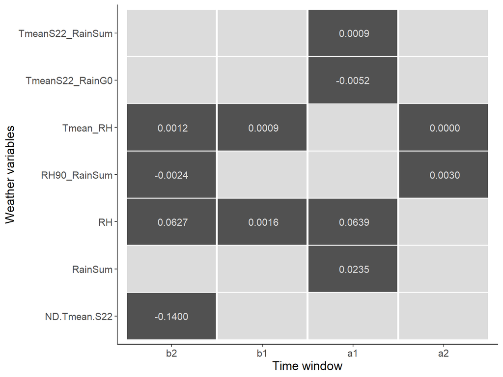

```r
#loading data
lasso = gsheet2tbl("https://docs.google.com/spreadsheets/d/1Xb-EYCW1EHYd5HAg12SSI18Ue4sb8411v7z9H7DSH0Q/edit#gid=452944216")

# Defines the colors for the squares
cores <- c("not selected" = "#dcdcdc", "selected" = '#515151')

 lasso %>%
  mutate(lasso = ifelse(lasso == 1, "selected", "not selected")) %>%
  mutate(window_panes = factor(window_panes, levels = c("b2", "b1", "a1", "a2"))) %>%
  ggplot(aes(x = window_panes, y = weather_variables, fill = lasso)) +
  geom_tile( width = 0.98, height = 0.98) +
  scale_y_discrete() +
  scale_fill_manual(values = cores) +
  labs(x = "Window Panes", y = "Weather Variables", fill = "LASSO") +
  theme_classic() +
  theme(legend.position = "none")+
   theme(text = element_text(size = 14))+
  labs(x = "Time window", y= "Weather variables")+
 geom_text(aes(label = ifelse(coef == 0, format(round(coef), nsmall = 0), format(round(coef, 4)))),
            size = 4, color = '#dcdcdc') # Formatação dos rótulos
```

```r
#ggsave('gr_lasso.png', width =5, height = 6, dpi = 500, bg = "white")
```

#FIGURE BEST SUBSET

Supplementary Fig. 1. Relationship between the number of variables and model evaluation metrics: A comprehensive analysis of log-likelihood (A) and Bayesian Information Criterion (B).

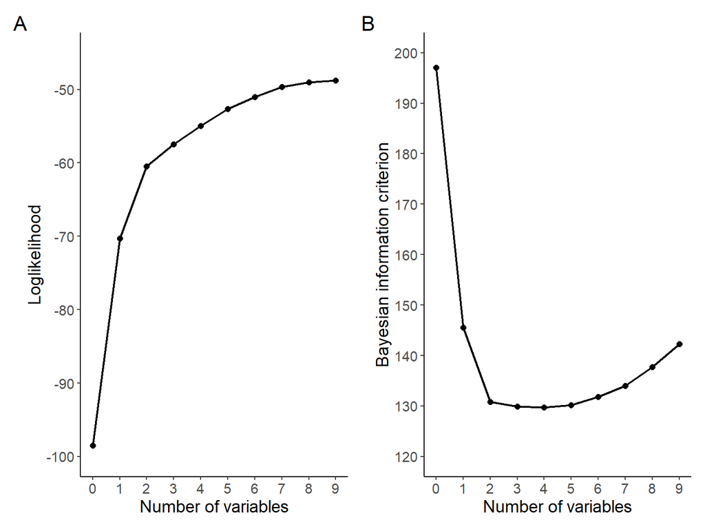

```r
best = gsheet2tbl("https://docs.google.com/spreadsheets/d/1Xb-EYCW1EHYd5HAg12SSI18Ue4sb8411v7z9H7DSH0Q/edit#gid=746618268")


# Set the font to Arial
loadfonts(device = "win")
font <- "Arial"

log = best %>%
  ggplot(aes(n_variaveis, loglike)) +
  geom_line( color = "black", linetype = "solid", size = 0.8) +
  geom_point(color = "black", size = 2, shape = 16) +
  scale_x_continuous(breaks = seq(0, 9, 1), limits = c(0, 9))+
   scale_y_continuous(breaks = seq(-100, -45, 10), limits = c(-100, -45))+
  labs(x = "Number of variables", y = "Loglikelihood") +
  theme_classic() + theme(text = element_text(family = font, size = 14))

bic = best %>%
  ggplot(aes(n_variaveis, bic)) +
  geom_line(color = "black", linetype = "solid", size = 0.8) +
  geom_point(color = "black", size = 2, shape = 16) +
  scale_x_continuous(breaks = seq(0, 9, 1), limits = c(0, 9))+
   scale_y_continuous(breaks = seq(120, 200, 10), limits = c(120,200))+
  labs(x = "Number of variables", y = "Bayesian information criterion") +
  theme_classic()+ theme(text = element_text(family = font, size = 14))



(log|bic) + plot_annotation(tag_levels = 'A')
```

```r
#ggsave('bestglm.png', width =10, height = 6, bg = "white", dpi = 1000)
```

# MODEL COMPARISON AND EXPERT EVALUATION

## Import data from Nasapower

```r
library(nasapower)
library(tidyverse)
library(patchwork)



uberaba <- get_power(community = "ag",
                      lonlat = c(-47.9340, -19.7460),
                      pars = c("RH2M", "T2M", "T2M_MAX",
                               "T2M_MIN", "PRECTOTCORR"),
                      dates = c("2000-01-01", "2023-09-15"),
                      temporal_api = "daily")


 passofundo<-  get_power(community = "ag",
                      lonlat = c(-52.4083, -28.2612),
                      pars = c("RH2M", "T2M", "T2M_MAX",
                               "T2M_MIN", "PRECTOTCORR"),
                      dates = c("2000-08-01", "2023-10-15"),
                      temporal_api = "daily")

 londrina <-  get_power(community = "ag",
                      lonlat = c(-51.1732, -23.2927),
                      pars = c("RH2M", "T2M", "T2M_MAX",
                               "T2M_MIN", "PRECTOTCORR"),
                      dates = c("2000-06-01", "2023-10-10"),
                      temporal_api = "daily")
```

## Function

```r
wheat_blast <- function(data, date_str){

  heading <- as.Date(date_str, origin = "1970-01-01")
  data2 <- data %>%
    mutate(
      heading = as.Date(heading),
      days = as.numeric(-(heading - YYYYMMDD))
    ) |>
    mutate(
      single_week = case_when(
        days < -21 ~ "NO",
        days >= -21 & days < -14 ~ "NO",
        days >= -14 & days < -7 ~ "wb2",
        days >= -7 & days <= 0 ~ "wb1",
        days > 0 & days <= 7 ~ "wa1",
        days > 7 & days <= 14 ~ "wa2",
        days > 14 & days <= 21 ~ "NO",
        days > 21 ~ "NO")
    ) |>
    filter(single_week != "NO") |>
    mutate(
      RH90t = ifelse(RH2M >= 90, 1, 0),
      ND.TMEAN.22_28 = ifelse(T2M >= 22 & T2M <= 28, 1, 0),
      ND.TMEAN.S22 = ifelse(T2M < 22, 1, 0),
      ND.TMEAN.G28 = ifelse(T2M > 28, 1, 0),
      RAIN.ND.G0 = ifelse(PRECTOTCORR > 0, 1, 0)
    ) |>
    group_by(single_week) |>
    summarise(
      RHM = mean(RH2M),
      RH90N = sum(RH90t),
      TMEANMAX = mean(T2M_MAX),
      TMEANMIN = mean(T2M_MIN),
      TMEAN = mean(T2M),
      ND.TMEAN.S22 = sum(ND.TMEAN.S22),
      RAINSUM = sum(PRECTOTCORR),
      RAIN.ND.G0 = sum(RAIN.ND.G0),
      INT4 = TMEAN*RHM
    ) |>
    pivot_wider(
      names_from = single_week,
      values_from = c(
        RHM,
        RH90N,
        TMEANMAX,
        TMEANMIN,
        TMEAN,
        ND.TMEAN.S22,
        RAINSUM,
        RAIN.ND.G0,
        INT4
      ),
      values_fill = 0
    )
# Calculo das probabilidades para cada modelo

   model1 <- -15.907922 + 0.136713 * data2$RHM_wa1 + 0.004216 * data2$INT4_wb2
  prob1 <- exp(model1) / (1 + exp(model1))

  model2 <- -10.84637 + 0.16417 * data2$RHM_wb2 - 0.32558 * data2$ND.TMEAN.S22_wb2 + 0.06925 * data2$RAINSUM_wa1
  prob2 <- exp(model2) / (1 + exp(model2))

  model3 <- -12.984671 + 0.141427 * data2$RHM_wb2 - 0.226089 * data2$ND.TMEAN.S22_wb2 + 0.068616 * data2$RAINSUM_wa1 + 0.002281 * data2$INT4_wb1
  prob3 <- exp(model3) / (1 + exp(model3))

  model4 <- -13.633025 + 0.052137 * data2$RHM_wa1 + 0.113687 * data2$RHM_wb2 - 0.264446 * data2$ND.TMEAN.S22_wb2 + 0.052856 * data2$RAINSUM_wa1 + 0.001763 * data2$INT4_wb1
  prob4 <- exp(model4) / (1 + exp(model4))

  # Retornar as probabilidades como parte do resultado da função
  data.frame(data = as.Date(date_str), prob1 = prob1, prob2 = prob2, prob3 = prob3, prob4 = prob4)
}
```

## Uberaba

```r
years <- 2000:2023
wheat_blast_list <- list()
for (year in years) {
  dates <- seq(as.Date(paste0(year, "-04-15")), as.Date(paste0(year, "-05-15")), by = "day")
  wheat_blast_list[[as.character(year)]] <- map_df(dates, ~ wheat_blast(uberaba, .))
}

uberaba3 <- reshape2::melt(wheat_blast_list, id.vars = "data")
#write_xlsx(uberaba_2000_2023, "caminho/do/arquivo.xlsx")


m_ub = uberaba3|>
 mutate(risk = case_when(
    variable == "prob1" & value > 0.43 ~ "high",
    variable == "prob2" & value > 0.44 ~ "high",
    variable == "prob3" & value > 0.68 ~ "high",
    variable == "prob4" & value > 0.62 ~ "high",
    TRUE ~ "low"
  ))

m1_ub = m_ub |> filter(variable == 'prob1') |>
  janitor::tabyl(L1,  risk) |>
   mutate(model = "1", freq = high / (low + high))

m2_ub = m_ub |> filter(variable == 'prob2') |>
  janitor::tabyl(L1,  risk) |>
   mutate(model = "2", freq = high / (low + high))


m3_ub = m_ub |> filter(variable == 'prob3') |>
  janitor::tabyl(L1,  risk) |>
   mutate(model = "3", freq = high / (low + high))

m4_ub = m_ub |> filter(variable == 'prob4') |>
  janitor::tabyl(L1,  risk) |>
   mutate(model = "4",freq = high / (low + high))


combined_df <- bind_rows(m2_ub, m1_ub, m3_ub, m4_ub)

p1 = combined_df %>%
  ggplot(aes(model, freq)) +
  geom_boxplot(fill = "white", color = "black", alpha = 0.6, width = 0.5) +
  labs(x = "", y = "", title = 'Uberaba, MG') +
  theme_classic() +
   scale_y_continuous(breaks = seq(0, 1, 0.1), limits = c(0, 1))

#######################################plot 2#########################################
mean(uberaba3$value)
```

```
[1] 0.7198703
```

```r
median(uberaba3$value)
```

```
[1] 0.7965553
```

```r
g2_u =uberaba3 |>
  filter(variable == 'prob3') |>
    mutate(risk = case_when(value > 0.68 ~ "high",
                          TRUE ~ "low")) |>
    janitor::tabyl(L1, risk) |>
  mutate(freq = high / (low + high)) |>
  ggplot(aes(L1, freq))+
  geom_col(fill = "#B22222")+
  labs(y = "Seasonal wheat blast risk index",
       x = "", title = 'Uberaba, MG') +
  theme_classic()+
   scale_y_continuous(breaks = seq(0, 1, 0.1), limits = c(0, 1))+
  theme(axis.text.x = element_text(angle = 90, hjust = 1)) +
  geom_hline(yintercept = 0.71, linetype = "dashed")
```